# Figure S1 Sampling

Mads Albertsen

March 10, 2015

## Load packages

```r
library("ampvis")
```

## Load data

```r
data(DNAext_1.0)
```

## Subset to the relevant samples

All samples are subset to 17.000 reads and then only OTUs which are seen at least 10 / 17000 times in a single sample is kept for further ordination analysis.

```r
rep <- subset_samples(V13, Exp.Biorep == "YES") %>%
  rarefy_even_depth(sample.size = 17000, rngseed = 712) %>%
  filter_taxa(function(x) max(x) >= 10, TRUE)
```

## Figure S1A: PCA colored by sampling site

PCA with square root transformed OTU abundances. The effect of sampling from different tanks is tested using the envfit function in vegan (permutation test).

```r
pca <- amp_ordinate(data = rep,
             plot.color = "Add.Label",
             plot.point.size = 3,
             plot.theme = "clean",
             envfit.factor = "Add.Label",
             envfit.show = F,
             output = "complete"
             )
```

It looks like there is no significant groupings.

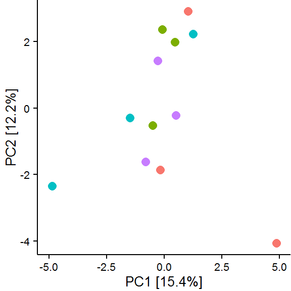

```r
pca$plot +
  scale_color_discrete(name = "Sampling site") +
  theme(legend.position = "none") +
  xlim(-5,5)
```

```r
ggsave("plots/S1A.eps", width = 55, height = 55, units = "mm")
```

The model reports a p-value of 0.529, hence there is no effect of sampling from different tanks.

```r
pca$eff.model
```

```
##
## ***FACTORS:
##
## Centroids:
##                      PC1     PC2
## Add.LabelTank1-A  1.9160 -1.0045
## Add.LabelTank1-B -0.0376  1.2777
## Add.LabelTank2-A -1.6910 -0.1374
## Add.LabelTank2-B -0.1874 -0.1357
##
## Goodness of fit:
##              r2 Pr(>r)
## Add.Label 0.259  0.529
## Permutation: free
## Number of permutations: 999
```

## Figure S1B: Cluster analysis of beta diversity using Bray-Curtis

The Bray-Curtis dissimilarity index is used as an alternative method to test for significant groupings in the dataset.

```r
beta <- amp_test_cluster(data = rep,
                         group = "Bio.Rep",
                         method = "bray",
                         plot.color = "Add.Label",
                         plot.label = "Add.Label",
                         plot.theme = "clean")
```

Using adonis we do not find a significant effect either as the p-value is 0.111.

```r
beta$adonis
```

```
##
## Call:
## adonis(formula = test_formula, data = sample)
##
## Permutation: free
## Number of permutations: 999
##
## Terms added sequentially (first to last)
##
##           Df SumsOfSqs   MeanSqs F.Model      R2 Pr(>F)
## Bio.Rep    3  0.025534 0.0085112   1.132 0.29801  0.111
## Residuals  8  0.060148 0.0075185         0.70199
## Total     11  0.085682                   1.00000
```

Clustering the data show a similar trend, no grouping by sampling site.

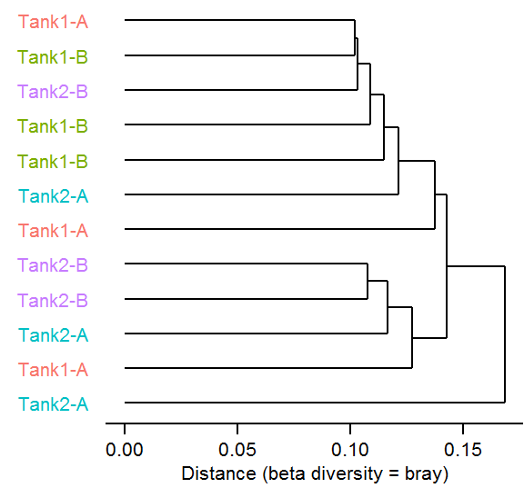

```r
beta$plot_cluster +
  theme(legend.position = "none")
```

```r
ggsave("plots/S1B.eps", width = 60, height = 55, units = "mm")
```

## Variation on OTU level

### Subset to the relevant samples

The samples are subset to 32.000 reads. 1 of 12 biological replicates is discarded as it only had 17.000 reads.

```r
rr <- subset_samples(V13, Exp.Biorep == "YES") %>%
  rarefy_even_depth(sample.size = 32000, rngseed = 712)
```

## Calculate 95% confidence interval

The 95% confidence interval for each OTU is calculated in order to compare the variation as a function of sequencing depth. The confidence interval is expressed as % of the mean count in order to compare across sequencing depth. The population standard deviation is estimated from the 11 samples and the confidence interval is calculated using 3 samples.

```r
data <- data.frame(OTU = rownames(otu_table(rr)@.Data), otu_table(rr)@.Data) %>%
  melt(id.vars = "OTU", value.name = "Count", variable.name = "Sample") %>%
  group_by(OTU) %>%
  summarise(Mean = mean(Count),
            pRR = sd(Count)*qt(0.975,df = n()-1)/mean(Count)*100,
            pCI3 = (sd(Count)*qt(0.975,df = n()-1)/sqrt(3))/mean(Count)*100)
```

## Figure S1C: 95% confidence interval as function of mean OTU count

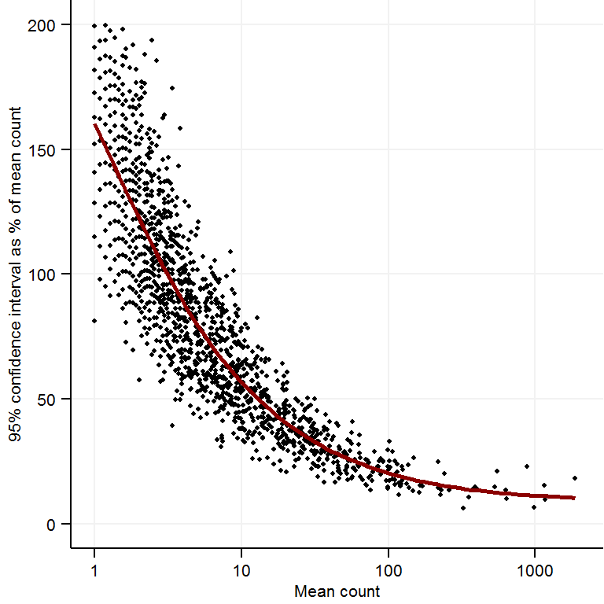

```r
ggplot(data, aes(x = Mean, y = pCI3)) +
  geom_point(size = 1) +
  geom_smooth(se = F, color = "darkred", size = 1) +
  scale_x_log10(limits=c(1,2000), breaks = c(1, 10, 100, 1000)) +
  ylim(0,200) +
  xlab("Mean count") +
  ylab("95% confidence interval as % of mean count") +
  theme(legend.position = "none",
        text = element_text(size = 8, color = "black"),
        axis.text = element_text(size = 8, color = "black"),
        axis.text.y = element_text(hjust = 1),
        plot.margin = unit(c(0,0,0,0), "mm"),
        axis.line = element_line(color = "black"),
        panel.grid.minor = element_blank(),
        panel.grid.major = element_line(color = "grey95"),
        axis.ticks = element_line(color = "black"),
        panel.background = element_blank()
        )
```

```r
ggsave("plots/S1C.eps", width = 100, height = 100, units = "mm")
```